# Calcification and Survival Data Analyses and Visualization *(Castillo et al In Prep)*

Colleen B Bove

Last run on 13 February 2023

## *In situ* temperature

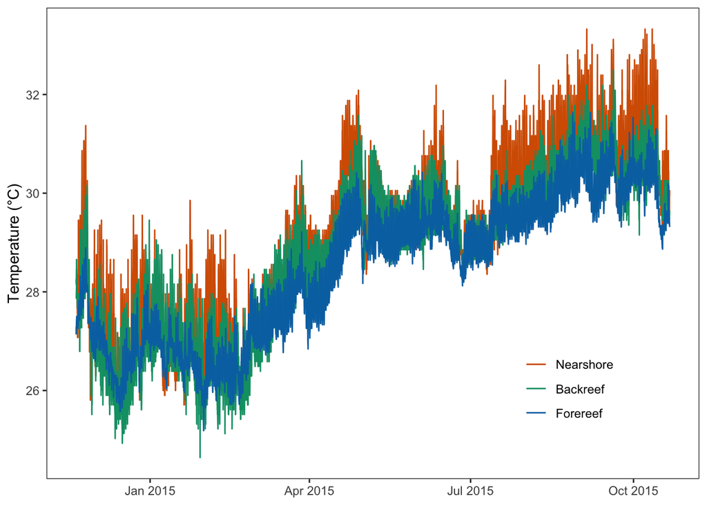

### Overall temperatures

| reef | Mean | SD | Min | Max | N | SE |
| --- | --- | --- | --- | --- | --- | --- |
| Nearshore | 29.1 | 1.66 | 25.5 | 33.3 | 16088 | 0.0130875 |
| Backreef | 28.7 | 1.61 | 24.6 | 32.5 | 16088 | 0.0126933 |
| Forereef | 28.5 | 1.42 | 25.2 | 31.6 | 16088 | 0.0111953 |

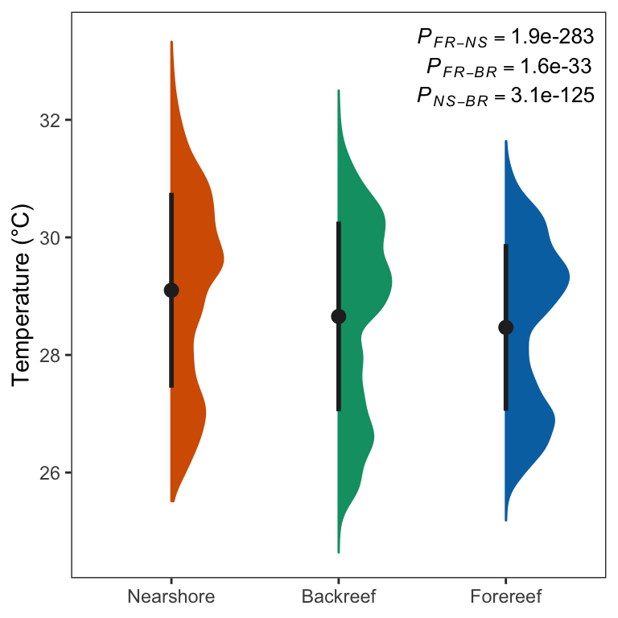

### Mean temperatures

Means (monthly, weekly, daily)

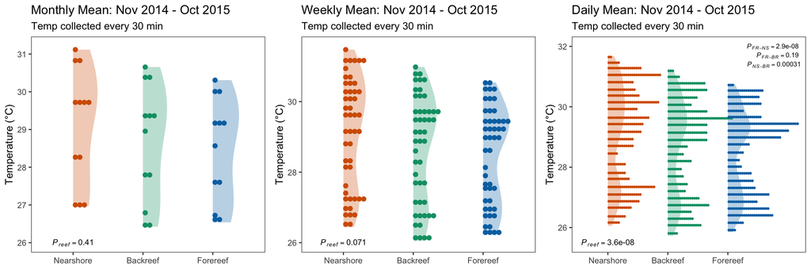

### Temperature ranges

Ranges (monthly, weekly, daily)

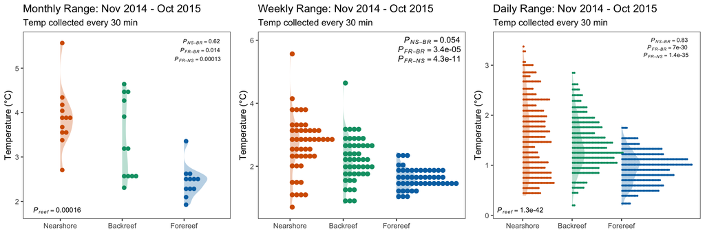

## Colony survival

### Figure 2A

#### **Data Visualization**

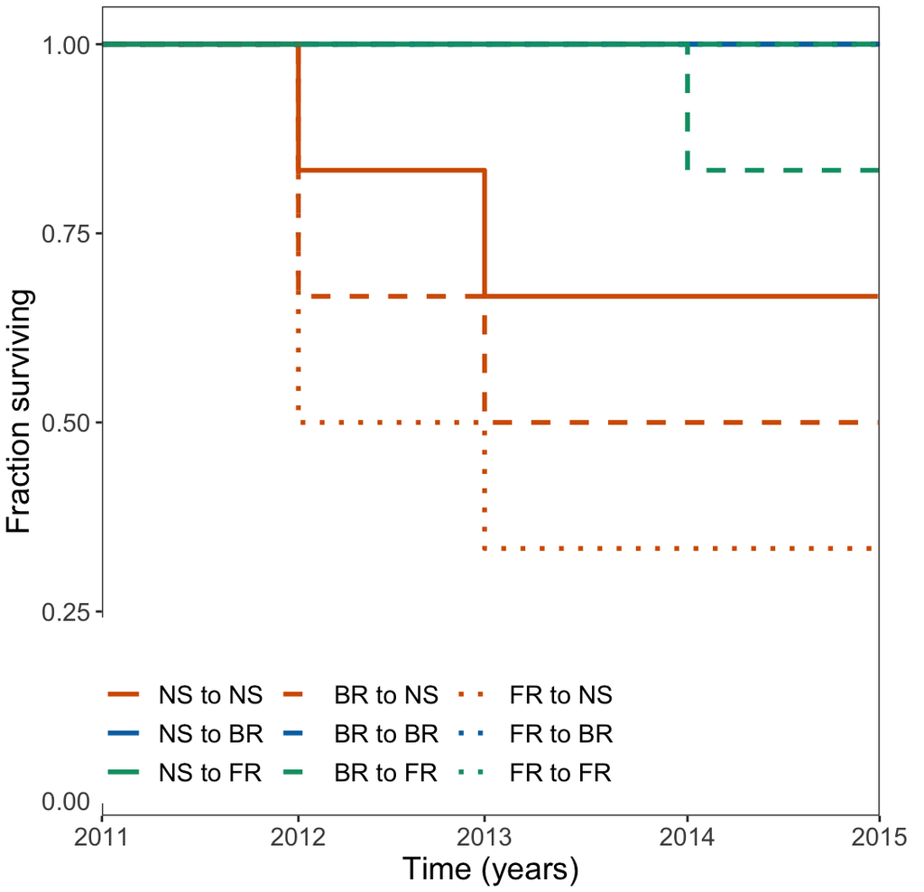

### Supplementary Table 4

**Table S4.** Number or corals surviving per year in each transplant location (BR = backreef, FR = forereef, NS = Nearshore).

| Source | Transplant | 2011 | 2012 | 2013 | 2014 | 2015 |
| --- | --- | --- | --- | --- | --- | --- |
| BR | BR | 6 | 6 | 6 | 6 | 6 |
| BR | FR | 6 | 6 | 6 | 5 | 5 |
| BR | NS | 6 | 4 | 3 | 3 | 3 |
| FR | BR | 6 | 6 | 6 | 6 | 6 |
| FR | FR | 6 | 6 | 6 | 6 | 6 |
| FR | NS | 6 | 3 | 2 | 2 | 2 |
| NS | BR | 6 | 6 | 6 | 6 | 6 |
| NS | FR | 6 | 6 | 6 | 6 | 6 |
| NS | NS | 6 | 5 | 4 | 4 | 4 |

### Statistical Exploration

##### While the current data are not able to be appropriately fit with statistical models, here are the models we explored:

#### **Cox Proportional Hazard Model**

```r
surv.mod <- coxph(sur.r ~ Transplant + Source, data = sur)
```

Cox proportional hazard model output, with exp(coef) representing the hazard ratio, se(coef) is the standard error, z is the z score, and Pr(>|z|) is the propability that the estimated could be 0.

|  | coefficient | exp(coef) | se(coef) | z | Pr(>\|z\|) |
| --- | --- | --- | --- | --- | --- |
| TransplantBR | -21.46 | 0.00 | 12566.10 | 0.00 | 1.00 |
| TransplantFR | -2.58 | 0.08 | 1.06 | -2.44 | 0.01 |
| SourceBR | 0.84 | 2.31 | 0.87 | 0.96 | 0.33 |
| SourceFR | 1.00 | 2.72 | 0.87 | 1.15 | 0.25 |

ANOVA output of the survival model.

|  | loglik | Chisq | Df | Pr(>\|Chi\|) |
| --- | --- | --- | --- | --- |
| NULL | -39.003 |  |  |  |
| Transplant | -29.375 | 19.256 | 2 | 0.000 |
| Source | -28.564 | 1.622 | 2 | 0.444 |

## Calcification rate

### Overall Calcification Statistics

#### **Model selection**

**Overall calcification Akaike information criterion (AIC) model selection** Model selection for assessment of source and transplant location impacts on overall (2012 - 2015) coral calcification rates was performed using AIC. The model with the lowest AIC (in bold) best fit the data and was used for analyses.

|  | df | AIC |
| --- | --- | --- |
| Source * Transplant | 10 | -15.05 |
| Source + Transplant | 6 | -8.51 |
| Transplant only | 4 | -7.76 |
| Source only | 4 | -12.34 |

#### **Modelling Parametric Bootstrap 95% Confidence Intervals**

Model:

```r
calc.model <- lm(rate ~ source * trans, data = RT.calc.fin) # selected model
```

**Modeled Mean Calcification Rate and 95% Confidence Interval**

Parametric bootstrapped mean and 95% confidence intervals of calcification rates (mg cm<sup>-2</sup> day<sup>-1</sup>) in response to transplant treatment (BR = backreef, FR = forereef, NS = Nearshore).

| Treatment | Modeled Mean | Lower 95% CI | Upper 95% CI |
| --- | --- | --- | --- |
| BR to BR | 0.68 | 0.52 | 0.85 |
| BR to FR | 0.64 | 0.45 | 0.83 |
| BR to NS | 0.88 | 0.64 | 1.11 |
| FR to BR | 1.00 | 0.83 | 1.16 |
| FR to FR | 0.91 | 0.78 | 1.04 |
| FR to NS | 0.56 | 0.32 | 0.80 |
| NS to BR | 0.74 | 0.58 | 0.91 |
| NS to FR | 0.76 | 0.61 | 0.90 |
| NS to NS | 0.88 | 0.72 | 1.04 |

### Figure 2B

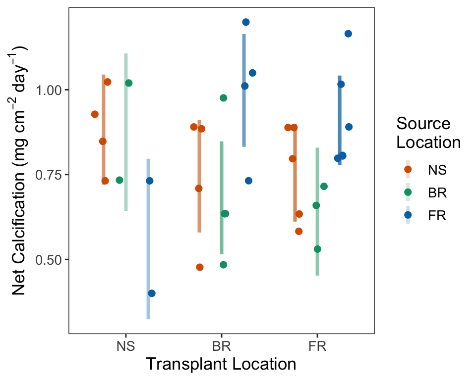

**Figure 2B.** Calcification rate (mg cm<sup>–2</sup> day<sup>–1</sup>) averaged over the entire transplant experimental period (2012 – 2015) by transplant location. Source location is represented by color: orange = NS (nearshore), green = BR (backreef), and blue = FR (forereef). Colored bars represent modeled 95% confidence intervals with corresponding raw calcification rates per colony denoted by circles of the same color.

### Calcification by Year

#### **Model selection**

**Year calcification Akaike information criterion (AIC) model selection**

Model selection for assessment of source and transplant location impacts on Year coral calcification rates was performed using AIC. The model in bold appropriately fit the data and was used for analyses.

|  | df | AIC |
| --- | --- | --- |
| Source * Transplant * Year | 28 | 6.48 |
| Source + Transplant + Year | 8 | 19.38 |
| Source * Transplant + Year | 12 | 10.25 |
| Source * Year + Transplant | 12 | 24.21 |
| Transplant * Year + Source | 12 | 6.24 |
| Transplant only | 4 | 67.55 |
| Source only | 4 | 61.23 |
| Year only | 4 | 19.68 |

#### **Modelling Parametric Bootstrap 95% Confidence Intervals**

Model:

```r
tp.model <- lm(rate ~ source * trans * TP, data = RT.calc.tp) # selected model
```

**Modeled Mean Calcification Rate and 95% Confidence Interval by Year**

Parametric bootstrapped mean and 95% confidence intervals of calcification rates (mg cm<sup>-2</sup> day<sup>-1</sup>) in response to transplant treatment (BR = backreef, FR = forereef, NS = Nearshore) over time.

| Treatment | Modeled Mean | Lower 95% CI | Upper 95% CI |
| --- | --- | --- | --- |
| BR to BR in 2013 | 0.53 | 0.35 | 0.71 |
| BR to BR in 2014 | 0.61 | 0.43 | 0.79 |
| BR to BR in 2015 | 0.96 | 0.74 | 1.17 |
| BR to FR in 2013 | 0.58 | 0.36 | 0.80 |
| BR to FR in 2014 | 0.41 | 0.18 | 0.63 |
| BR to FR in 2015 | 0.93 | 0.67 | 1.18 |
| BR to NS in 2013 | 0.57 | 0.34 | 0.78 |
| BR to NS in 2014 | 0.62 | 0.32 | 0.93 |
| BR to NS in 2015 | 1.48 | 1.18 | 1.80 |
| FR to BR in 2013 | 0.78 | 0.60 | 0.95 |
| FR to BR in 2014 | 0.83 | 0.65 | 1.01 |
| FR to BR in 2015 | 1.26 | 1.05 | 1.48 |
| FR to FR in 2013 | 0.99 | 0.82 | 1.17 |
| FR to FR in 2014 | 0.70 | 0.53 | 0.88 |
| FR to FR in 2015 | 1.05 | 0.86 | 1.23 |
| FR to NS in 2013 | 0.52 | 0.26 | 0.78 |
| FR to NS in 2014 | 0.25 | -0.06 | 0.57 |
| FR to NS in 2015 | 0.99 | 0.67 | 1.29 |
| NS to BR in 2013 | 0.59 | 0.39 | 0.79 |
| NS to BR in 2014 | 0.76 | 0.57 | 0.96 |
| NS to BR in 2015 | 0.92 | 0.70 | 1.13 |
| NS to FR in 2013 | 0.79 | 0.61 | 0.96 |
| NS to FR in 2014 | 0.67 | 0.49 | 0.86 |
| NS to FR in 2015 | 0.84 | 0.62 | 1.05 |
| NS to NS in 2013 | 0.73 | 0.50 | 0.95 |
| NS to NS in 2014 | 0.59 | 0.38 | 0.80 |
| NS to NS in 2015 | 1.33 | 1.12 | 1.55 |

#### **Data Visualization**

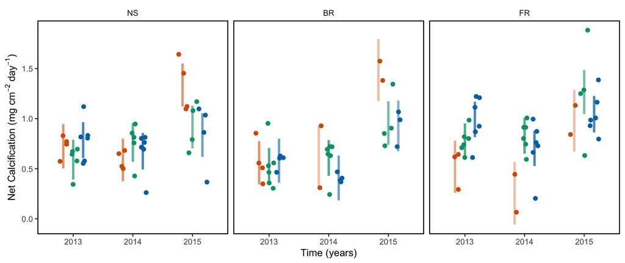

**Figure 3B |** Calcification rate (mg cm<sup>-2</sup> day<sup>-1</sup>) at yearly intervals over the entire transplant experimental period (2012 – 2015) by source location. Transplant location is represented by color: red = NS (nearshore), green = BR (backreef), and blue = FR (forereef). Colored bars represent modeled 95% confidence intervals with corresponding raw calcification rates per colony denoted by circles of the same color.

### Supplemental Tables

#### Supplemental Table 1

|  | df | AIC |
| --- | --- | --- |
| **Overall Calcification** |  |  |
| Source * Transplant | 10 | -15.05 |
| Source + Transplant | 6 | -8.51 |
| Transplant only | 4 | -7.76 |
| Source only | 4 | -12.34 |
| **Annual Calcification** |  |  |
| Source * Transplant * Year | 28 | 6.48 |
| Source + Transplant + Year | 8 | 19.38 |
| Source * Transplant + Year | 12 | 10.25 |
| Source * Year + Transplant | 12 | 24.21 |
| Transplant * Year + Source | 12 | 6.24 |
| Transplant only | 4 | 67.55 |
| Source only | 4 | 61.23 |
| Year only | 4 | 19.68 |

#### Supplemental Table 5

**Table S5** Linear model output assessing overall calcification responses. The intercept was set at corals from the backreef (BR) transplanted back to the backreef.

|  | Estimate | Std. Error | t value | Pr(>\|t\|) |
| --- | --- | --- | --- | --- |
| (Intercept) | 0.68 | 0.08 | 8.10 | 0.00 |
| source (FR) | 0.32 | 0.12 | 2.65 | 0.01 |
| source (NS) | 0.06 | 0.12 | 0.49 | 0.63 |
| transplant (FR) | -0.05 | 0.13 | -0.37 | 0.72 |
| transplant (NS) | 0.19 | 0.15 | 1.33 | 0.20 |
| source (FR):transplant (FR) | -0.04 | 0.17 | -0.22 | 0.83 |
| source (NS):transplant (FR) | 0.07 | 0.17 | 0.38 | 0.71 |
| source (FR):transplant (NS) | -0.63 | 0.21 | -3.03 | 0.01 |
| source (NS):transplant (NS) | -0.05 | 0.19 | -0.28 | 0.78 |

#### Supplemental Table 6

**Table S6.** Modeled mean calcification rate and 95% confidence interval. Parametric bootstrapped mean and 95% confidence intervals of calcification rates (mg cm<sup>-2</sup> day<sup>-1</sup>) in response to transplant treatment (BR = backreef, FR = forereef, NS = Nearshore).

| Treatment | Modeled Mean | Lower 95% CI | Upper 95% CI |
| --- | --- | --- | --- |
| BR to BR | 0.68 | 0.52 | 0.85 |
| BR to FR | 0.64 | 0.45 | 0.83 |
| BR to NS | 0.88 | 0.64 | 1.11 |
| FR to BR | 1.00 | 0.83 | 1.16 |
| FR to FR | 0.91 | 0.78 | 1.04 |
| FR to NS | 0.56 | 0.32 | 0.80 |
| NS to BR | 0.74 | 0.58 | 0.91 |
| NS to FR | 0.76 | 0.61 | 0.90 |
| NS to NS | 0.88 | 0.72 | 1.04 |

#### Supplemental Table 7

|  | Estimate | Std. Error | t value | Pr(>\|t\|) |
| --- | --- | --- | --- | --- |
| (Intercept) | 0.53 | 0.09 | 5.79 | 0.00 |
| source (FR) | 0.25 | 0.13 | 1.94 | 0.06 |
| source (NS) | 0.06 | 0.14 | 0.44 | 0.66 |
| transplant (FR) | 0.05 | 0.14 | 0.34 | 0.74 |
| transplant (NS) | 0.04 | 0.14 | 0.27 | 0.78 |
| Year (2014) | 0.08 | 0.13 | 0.63 | 0.53 |
| Year (2015) | 0.43 | 0.14 | 2.98 | 0.00 |
| source (FR):transplant (FR) | 0.16 | 0.19 | 0.85 | 0.40 |
| source (NS):transplant (FR) | 0.15 | 0.20 | 0.75 | 0.45 |
| source (FR):transplant (NS) | -0.30 | 0.21 | -1.40 | 0.17 |
| source (NS):transplant (NS) | 0.10 | 0.21 | 0.50 | 0.62 |
| source (FR):Year (2014) | -0.03 | 0.18 | -0.17 | 0.87 |
| source (NS):Year (2014) | 0.09 | 0.19 | 0.48 | 0.63 |
| source (FR):Year (2015) | 0.06 | 0.20 | 0.27 | 0.79 |
| source (NS):Year (2015) | -0.09 | 0.21 | -0.44 | 0.66 |
| transplant (FR):Year (2014) | -0.25 | 0.20 | -1.23 | 0.22 |
| transplant (NS):Year (2014) | -0.03 | 0.23 | -0.13 | 0.90 |
| transplant (FR):Year (2015) | -0.08 | 0.22 | -0.36 | 0.72 |
| transplant (NS):Year (2015) | 0.48 | 0.24 | 1.99 | 0.05 |
| source (FR):transplant (FR):Year (2014) | -0.09 | 0.27 | -0.32 | 0.75 |
| source (NS):transplant (FR):Year (2014) | -0.03 | 0.28 | -0.11 | 0.91 |
| source (FR):transplant (NS):Year (2014) | -0.28 | 0.34 | -0.85 | 0.40 |
| source (NS):transplant (NS):Year (2014) | -0.28 | 0.31 | -0.90 | 0.37 |
| source (FR):transplant (FR):Year (2015) | -0.35 | 0.30 | -1.19 | 0.24 |
| source (NS):transplant (FR):Year (2015) | -0.20 | 0.31 | -0.66 | 0.51 |
| source (FR):transplant (NS):Year (2015) | -0.50 | 0.35 | -1.43 | 0.16 |
| source (NS):transplant (NS):Year (2015) | -0.22 | 0.32 | -0.68 | 0.50 |

#### Supplemental Table 8

**Table S8.** Modeled mean calcification rate and 95% confidence interval by year. Parametric bootstrapped mean and 95% confidence intervals of calcification rates (mg cm<sup>-2</sup> day<sup>-1</sup>) in response to transplant treatment (BR = backreef, FR = forereef, NS = Nearshore) over time.

| Treatment | Modeled Mean | Lower 95% CI | Upper 95% CI |
| --- | --- | --- | --- |
| BR to BR in 2013 | 0.53 | 0.35 | 0.71 |
| BR to BR in 2014 | 0.61 | 0.43 | 0.79 |
| BR to BR in 2015 | 0.96 | 0.74 | 1.17 |
| BR to FR in 2013 | 0.58 | 0.36 | 0.80 |
| BR to FR in 2014 | 0.41 | 0.18 | 0.63 |
| BR to FR in 2015 | 0.93 | 0.67 | 1.18 |
| BR to NS in 2013 | 0.57 | 0.34 | 0.78 |
| BR to NS in 2014 | 0.62 | 0.32 | 0.93 |
| BR to NS in 2015 | 1.48 | 1.18 | 1.80 |
| FR to BR in 2013 | 0.78 | 0.60 | 0.95 |
| FR to BR in 2014 | 0.83 | 0.65 | 1.01 |
| FR to BR in 2015 | 1.26 | 1.05 | 1.48 |
| FR to FR in 2013 | 0.99 | 0.82 | 1.17 |
| FR to FR in 2014 | 0.70 | 0.53 | 0.88 |
| FR to FR in 2015 | 1.05 | 0.86 | 1.23 |
| FR to NS in 2013 | 0.52 | 0.26 | 0.78 |
| FR to NS in 2014 | 0.25 | -0.06 | 0.57 |
| FR to NS in 2015 | 0.99 | 0.67 | 1.29 |
| NS to BR in 2013 | 0.59 | 0.39 | 0.79 |
| NS to BR in 2014 | 0.76 | 0.57 | 0.96 |
| NS to BR in 2015 | 0.92 | 0.70 | 1.13 |
| NS to FR in 2013 | 0.79 | 0.61 | 0.96 |
| NS to FR in 2014 | 0.67 | 0.49 | 0.86 |
| NS to FR in 2015 | 0.84 | 0.62 | 1.05 |
| NS to NS in 2013 | 0.73 | 0.50 | 0.95 |
| NS to NS in 2014 | 0.59 | 0.38 | 0.80 |
| NS to NS in 2015 | 1.33 | 1.12 | 1.55 |

### Supplemental Figures

#### Figure S2

[figure not shown]

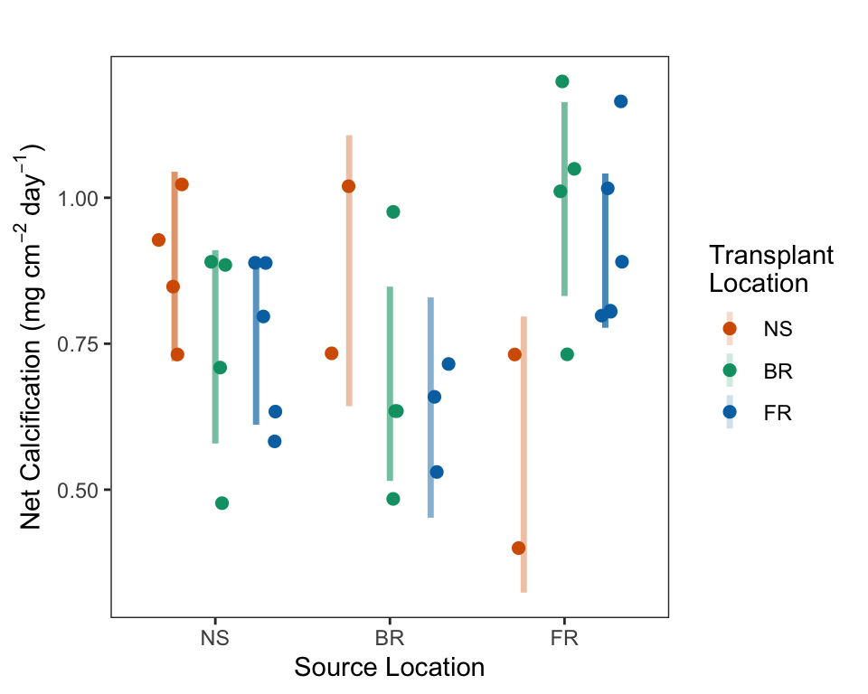

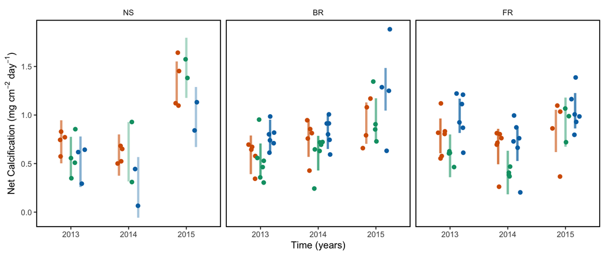

**Supplemental 1B |** Calcification rate (mg cm<sup>-2</sup> day<sup>-1</sup>) at yearly intervals over the entire transplant experimental period (2012 – 2015) by transplant location. Source location is represented by color: red = NS (nearshore), green = BR (backreef), and blue = FR (forereef). Colored bars represent modeled 95% confidence intervals with corresponding raw calcification rates per colony denoted by circles of the same color.

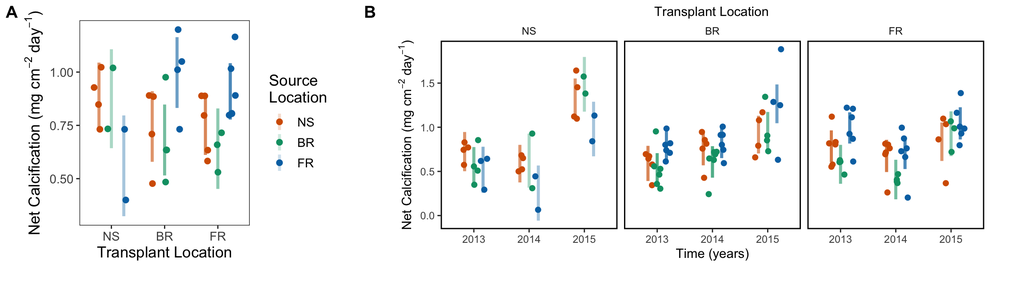

**Supplemental Figure 1.** Calcification rate (mg cm<sup>–2</sup> day<sup>–1</sup>) averaged over the entire transplant experimental period (2012 – 2015) by transplant location (A) and at yearly intervals (B). Source location is represented by color: red = NS (nearshore), green = BR (backreef), and blue = FR (forereef). Colored bars represent modeled 95% confidence intervals with corresponding raw calcification rates per colony denoted by circles of the same color.

## GE Plasticity Tables

### Supplemental Table S3

*(These model outputs are taken from the plasticity analysis and just constructed into tables here)*

**Table S3.** Akaike information criterion (AIC) model selection for coral host and algal symbiont gene expression plasticity. Model selection for assessment of source and transplant location impacts on gene expression plasticity performed using AIC.

| Host Model | AIC | BIC | Nagelkerke’s R2 |
| --- | --- | --- | --- |
| Source * Transplant | 46.845 | 64.687 | 0.833 |
| Source + Transplant | 102.088 | 112.794 | 0.146 |
| Transplant | 99.632 | 106.769 | 0.108 |
| Source | 102.398 | 109.535 | 0.034 |

| Symbiont Model | AIC | BIC | Nagelkerke’s R2 |
| --- | --- | --- | --- |
| Source * Transplant | 31.742 | 46.714 | 0.863 |
| Source + Transplant | 94.949 | 104.930 | 0.038 |
| Transplant | 91.827 | 98.481 | 0.011 |
| Source | 91.317 | 97.971 | 0.027 |

*(These model outputs are taken from the plasticity analysis and just constructed into tables here)*

|  | Estimate | Std. Error | t value | Pr(>t) |
| --- | --- | --- | --- | --- |
| *(Intercept)* | -0.6692 | 0.1731 | -3.866 | 0.000460 *** |
| Source (FR) | 1.1464 | 0.2448 | 4.683 | 4.17e-05 *** |
| Source (NS) | 0.6369 | 0.2568 | 2.481 | 0.018072 * |
| Transplant (FR) | 1.1503 | 0.2448 | 4.699 | 3.97e-05 *** |
| Transplant (NS) | 0.0778 | 0.2998 | 0.259 | 0.796787 |
| Source (FR):Transplant (FR) | -3.0430 | 0.3462 | -8.789 | 2.22e-10 *** |
| Source (NS):Transplant (FR) | -0.2569 | 0.3548 | -0.724 | 0.473857 |
| Source (FR):Transplant (NS) | 0.1188 | 0.4580 | 0.259 | 0.796844 |
| Source (NS):Transplant (NS) | -1.5480 | 0.4133 | -3.746 | 0.000647 *** |

*(These model outputs are taken from the plasticity analysis and just constructed into tables here)*

|  | Estimate | Std. Error | t value | Pr(>t) |
| --- | --- | --- | --- | --- |
| *(Intercept)* | -1.2588 | 0.1355 | -9.290 | 1.80e-10 *** |
| Source (FR) | 1.7762 | 0.1916 | 9.270 | 1.90e-10 *** |
| Source (NS) | 1.5797 | 0.2142 | 7.374 | 2.66e-08 *** |
| Transplant (FR) | 1.5676 | 0.1916 | 8.181 | 3.06e-09 *** |
| Transplant (NS) | 2.0990 | 0.2347 | 8.944 | 4.29e-10 *** |
| Source (FR):Transplant (FR) | -2.9321 | 0.2710 | -10.820 | 4.72e-12 *** |
| Source (NS):Transplant (FR) | -1.0877 | 0.3030 | -3.590 | 0.00112 ** |
| Source (FR):Transplant (NS) | *NA* | *NA* | *NA* | *NA* |
| Source (NS):Transplant (NS) | -3.0780 | 0.3319 | -9.274 | 1.88e-10 *** |

## Final figures

### Figure 1

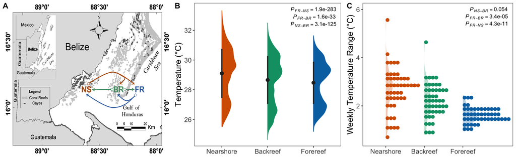

### Figure 2

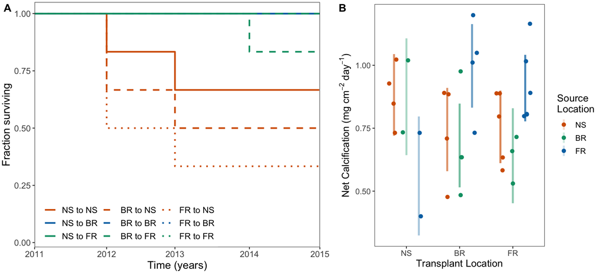

## *Session Information:*

*Last run on 13 February 2023*